# Blue Check: Weighing the Validity of Twitter Verified as a Social Status Indicator

# 1. Introduction

# 2. Methods and Results

First and foremost, we utilized these R libraries to perform our analysis:

- Tidyverse (for cleaning/wrangling and visualization)
- Caret (for the knn-classification algorithm)
- Expss (for tables and labels)

Because of the nature of our dataset, we deemed scaling, standardizing, and balancing our data was necessary before proceeding with our knn-classification. This is because accounts on Twitter usually have a disproportionate amount of likes compared to posts, or followers compared to posts, and so on. Thus, we utilized the preProcess function in caret to perform this task. Once we knew our data was properly set up, we split it into training/testing sets using a 0.75/0.25 split. After cleaning, analysis was performed to determine whether a twitter account is verified (class) based on three different groupings of variables: the number of followers, posts, likes, and friends (mutual followers). These were the numerical variables that could be used to determine the class. To determine which group of variables would produce the most accurate results, they were grouped into three pairings:

- Follower+post count
- Friend+like count
- Follower, post, and like count.

Using 10-fold cross-validation to choose k, the most accurate value for each group was determined by plotting k values as multiples of 10 against the prediction accuracy for that k value. The most accurate k value was found to be 1. Though we initially doubted using k = 1 because we thought it might skew the accuracy of our predictions (overfitting), further research indicated that using 1 as the k-value was actually the most optimal for our experiment in terms of efficiency and accuracy based on the superfluous nature of the dataset ("Can k," 2020)).

## 2.1 Installing Packages

```r
install.packages("expss")
```

```r
library("tidyverse")
library("caret")
library("expss")
set.seed(1234)
```

[output not shown]

## 2.2 Reading and Checking Data

```r
d <-read_csv("https://raw.githubusercontent.com/knt-tky-van/DSCI_100/master/twitterdata.csv")


d <- d %>%
    mutate(is_verified=cut(is_verified, breaks=c(-1,0.5,Inf), labels=c("Unverified","Verified")))

d$is_protected <- as.factor(d$is_protected)

report <- list()
report[[1]] <- "Table 1. Twitter Verification Data"
report[[2]] <- head(d)
report
```

1. 'Table 1. Twitter Verification Data'

2. A tibble: 6 × 11

   | Twitter_ID <dbl> | Twitter_User <chr> | Creation_Date <dbl> | Follower_Count <dbl> | Friend_Count <dbl> | Post_Count <dbl> | Liked_Count <dbl> | List_Count <dbl> | Language <chr> | is_protected <fct> | is_verified <fct> |
   | --- | --- | --- | --- | --- | --- | --- | --- | --- | --- | --- |
   | 9.99e+17 | NintendoLaboFR | 1526983527 | 3014 | 0 | 10 | 0 | 5 | en | 0 | Verified |
   | 9.99e+17 | Zero21Dec | 1526982877 | 5829 | 6 | 158 | 1 | 3 | en | 0 | Verified |
   | 9.99e+17 | GoogleCloud_IN | 1526951259 | 368 | 90 | 94 | 276 | 1 | en | 0 | Verified |
   | 9.99e+17 | tver_fwc | 1526909603 | 4898 | 66 | 89 | 2 | 36 | ja | 0 | Verified |
   | 9.97e+17 | ImKRUNKKK | 1526633047 | 1323 | 7 | 25 | 1 | 1 | en | 0 | Verified |
   | 9.97e+17 | PUBGEsports | 1526584590 | 17939 | 36 | 48 | 12 | 17 | en | 0 | Verified |

```r
# To see if "is_verified" colum has something other than "Unverified" and "Verified"
levels(d$is_verified)
```

1. 'Unverified'

2. 'Verified'

## 2.3 Balancing

```r
#Raw data
Raw <- d %>% group_by(is_verified) %>% summarize(n = n()) %>% rename(Verification=is_verified)

report_2 <- list()
report_2[[1]] <- "Table 2. The Number of Verified and Unverified Samples before Upsampling (0=Unverified, 1=Verified)"
report_2[[2]] <- Raw
report_2
```

1. 'Table 2. The Number of Verified and Unverified Samples before Upsampling (0=Unverified, 1=Verified)'

2. A tibble: 2 × 2

   | Verification <fct> | n <int> |
   | --- | --- |
   | Unverified | 972 |
   | Verified | 28 |

```r
#After upsample
data <- upSample(x = select(d, -is_verified),
            　　　y = select(d,is_verified) %>% unlist(),
                 yname="is_verified")

US <- data %>%
        group_by(is_verified) %>%
        summarize(n = n()) %>%
        rename(Verification=is_verified)

report_3 <- list()
report_3[[1]] <- "Table 3. The Number of Verified and Unverified Samples after Upsampling (0=Unverified, 1=Verified)"
report_3[[2]] <- US
report_3
```

1. 'Table 3. The Number of Verified and Unverified Samples after Upsampling (0=Unverified, 1=Verified)'

2. A tibble: 2 × 2

   | Verification <fct> | n <int> |
   | --- | --- |
   | Unverified | 972 |
   | Verified | 972 |

## 2.4 Splitting Data into Training/Test Sets

```r
set_rows <- data %>%
    select(is_verified) %>%
    unlist() %>%
    createDataPartition(p = 0.75, list = FALSE)

training_set <- data %>% slice(set_rows)
test_set <- data %>% slice(-set_rows)

scale_transformer <- preProcess(training_set, method = c("center", "scale"))

training_set <- predict(scale_transformer, training_set)
test_set <- predict(scale_transformer, test_set)
```

## 2.5 Summarize Raw Data and Training Data

### 2.5a Raw Data

```r
report_4 <- list()
report_4[[1]] <- "Table 4. Summary (Raw Data)"
report_4[[2]] <- summary(training_set %>% select(Follower_Count,Friend_Count,Post_Count,Liked_Count))
report_4
```

[output not shown]

```r
#how many rows are missing data
sum(is.na(d))
```

0

### 2.5b Training Data

```r
report_5 <- list()
report_5[[1]] <- "Table 5. Summary (Training Data)"
report_5[[2]] <- summary(training_set %>% select(Follower_Count,Friend_Count,Post_Count,Liked_Count))
report_5
```

```
[[1]]
[1] "Table 5. Summary (Training Data)"

[[2]]
 Follower_Count     Friend_Count         Post_Count        Liked_Count
 Min.   :-0.3486   Min.   :-0.414567   Min.   :-0.29414   Min.   :-0.3203
 1st Qu.:-0.3470   1st Qu.:-0.372090   1st Qu.:-0.28061   1st Qu.:-0.3180
 Median :-0.3217   Median :-0.253949   Median :-0.25356   Median :-0.2895
 Mean   : 0.0000   Mean   : 0.000000   Mean   : 0.00000   Mean   : 0.0000
 3rd Qu.:-0.2428   3rd Qu.:-0.008374   3rd Qu.:-0.09551   3rd Qu.:-0.1056
 Max.   : 4.7168   Max.   :12.862373   Max.   :16.55723   Max.   :11.2145
```

## 2.6 Visualize the Training Data

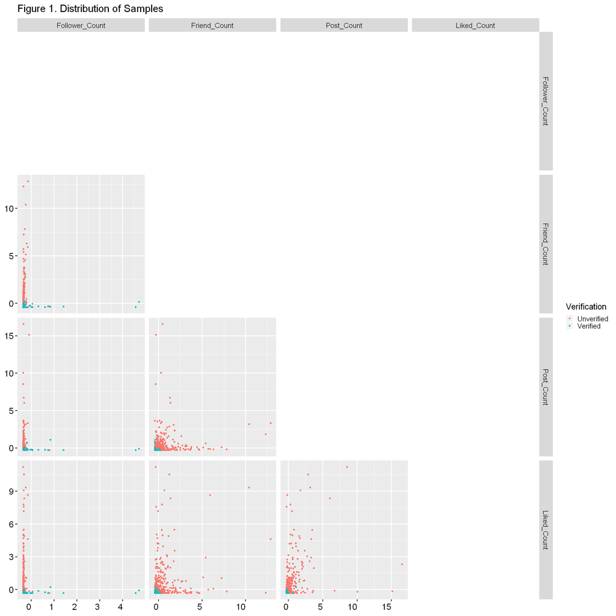

```r
library(GGally)
options(repr.plot.width = 20, repr.plot.height = 20)

plot_pairs <- training_set %>%
  select(Follower_Count,Friend_Count,Post_Count,Liked_Count,is_verified) %>%

  ggpairs(legend=5,
          columns=1:4,
          mapping = ggplot2::aes(color = is_verified),
          upper="blank",
          diag = NULL)+

          labs(color="Verification")+

          ggtitle("Figure 1. Distribution of Samples") +

          theme(plot.title = element_text(hjust = 1),
                axis.text.x = element_text(hjust = 1, color = "black",size=20),
                axis.text.y = element_text(hjust = 1, color = "black",size=20),
                legend.position = "bottom")+

          theme_grey(base_size = 20)

plot_pairs
```

- In a plot of Follower_Count and Post_Count or in a plot of Friend_Count and Liked_Count, the clusters of verified and unverified accounts seem most exclusive and distinct to each other compared to other plots. In addition, the two plots of Follower_Count and Post_Count and of Follower_Count and Liked_Count are quite similar in terms of the distribution of the two clusters. Therefore, in the classification phase we will use those three patterns: Follower_Count + Post_Count, Friend_Count + Liked_Count, and Follower_Count + Post_Count + Liked_Count.

## 2.7 Cleaning & Wrangling

- It was not necessary to clean and wrangle the original data since it was already tidy.

## 2.8 Cross-validation (10 folds) and Choosing K

### 2.8a Follower_Count and Post_Count

```r
# Split data into training and test sets
X_train_a <- training_set %>%
    select(Follower_Count, Post_Count) %>%
    data.frame()

Y_train <- training_set %>%
    select(is_verified) %>%
    unlist()

X_test_a <- test_set %>%
    select(Follower_Count, Post_Count) %>%
    data.frame()

Y_test <- test_set %>%
    select(is_verified) %>%
    unlist()
```

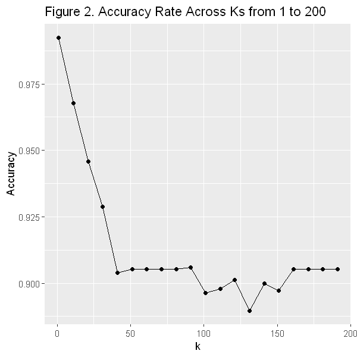

```r
# Choosing K (1) : which k is best roughly from 1 to 200?
options(repr.plot.width = 5, repr.plot.height = 5)

train_control <- trainControl(method="cv", number = 10)

k = data.frame(k = seq(from = 1, to = 200, by = 10))
knn_model_cv_10fold <- train(x = X_train_a, y = Y_train, method = "knn", tuneGrid = k, trControl = train_control)

accuracy <-knn_model_cv_10fold$results
accuracy_vs_k_lots <- ggplot(accuracy, aes(x = k, y = Accuracy)) +
  geom_point() +
  geom_line()+
  ggtitle("Figure 2. Accuracy Rate Across Ks from 1 to 200")
accuracy_vs_k_lots
```

[figure not shown]

```r
#choosing K(2): which k is best from 1 to 10?
train_control <- trainControl(method="cv", number = 10)
k = data.frame(k = c(1,2,3,4,5,6,7,8,9,10))

knn_model_cv_10fold <- train(x = X_train_a, y = Y_train, method = "knn", tuneGrid = k, trControl = train_control)
accuracy_2 <-knn_model_cv_10fold$results

accuracy_vs_k <- ggplot(accuracy_2, aes(x = k, y = Accuracy)) +
  geom_point() +
  geom_line()+
  ggtitle("Figure 3. Accuracy Rate Across Ks from 1 to 19")

accuracy_vs_k
```

### 2.8b Friend_Count and Liked_Count

```r
# Split data into training and test sets
X_train_b <- training_set %>%
    select(Friend_Count, Liked_Count) %>%
    data.frame()

X_test_b <- test_set %>%
    select(Friend_Count, Liked_Count) %>%
    data.frame()
```

```
$title
[1] "Figure 4. Accuracy Rate Across Ks from 1 to 200"

attr(,"class")
[1] "labels"
```

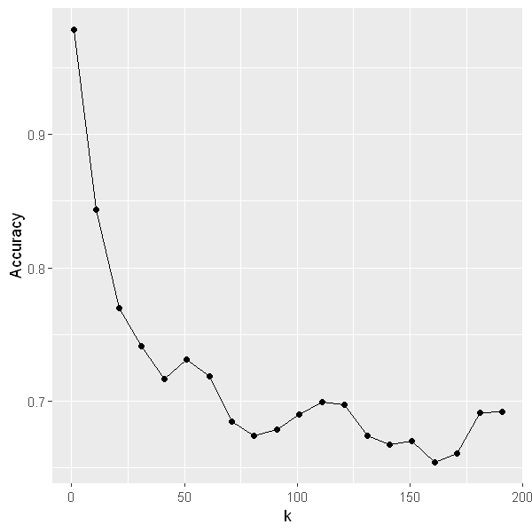

```r
# Choosing K (1) : which k is best roughly from 1 to 200?
train_control <- trainControl(method="cv", number = 10)
k = data.frame(k = seq(from = 1, to = 200, by = 10))

knn_model_cv_10fold <- train(x = X_train_b, y = Y_train, method = "knn", tuneGrid = k, trControl = train_control)

accuracy <-knn_model_cv_10fold$results
accuracy_vs_k_lots <- ggplot(accuracy, aes(x = k, y = Accuracy)) +
  geom_point() +
  geom_line()
  ggtitle("Figure 4. Accuracy Rate Across Ks from 1 to 200")
accuracy_vs_k_lots
```

[figure not shown]

```r
#choosing K(2): which k is best from 1 to 10?
train_control <- trainControl(method="cv", number = 10)
k = data.frame(k = c(1,2,3,4,5,6,7,8,9,10))

knn_model_cv_10fold <- train(x = X_train_b, y = Y_train, method = "knn", tuneGrid = k, trControl = train_control)
accuracy_2 <-knn_model_cv_10fold$results

accuracy_vs_k <- ggplot(accuracy_2, aes(x = k, y = Accuracy)) +
  geom_point() +
  geom_line()+
  ggtitle("Figure 5. Accuracy Rate Across Ks from 1 to 19")

accuracy_vs_k
```

### 2.8c Follower_Count, Post_Count, and Liked_Count

```r
# Split data into training and test sets
X_train_c <- training_set %>%
    select(Follower_Count,Post_Count, Liked_Count) %>%
    data.frame()

X_test_c <- test_set %>%
    select(Follower_Count,Post_Count, Liked_Count)%>%
    data.frame()
```

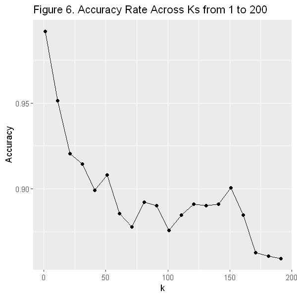

```r
# Choosing K (1) : which k is best roughly from 1 to 200?
train_control <- trainControl(method="cv", number = 10)
k = data.frame(k = seq(from = 1, to = 200, by = 10))

knn_model_cv_10fold <- train(x = X_train_c, y = Y_train, method = "knn", tuneGrid = k, trControl = train_control)

accuracy <-knn_model_cv_10fold$results
accuracy_vs_k_lots <- ggplot(accuracy, aes(x = k, y = Accuracy)) +
  geom_point() +
  geom_line()+
  ggtitle("Figure 6. Accuracy Rate Across Ks from 1 to 200")
accuracy_vs_k_lots
```

[figure not shown]

```r
#choosing K(2): which k is best from 1 to 10?
train_control <- trainControl(method="cv", number = 10)
k = data.frame(k = c(1,2,3,4,5,6,7,8,9,10))

knn_model_cv_10fold <- train(x = X_train_c, y = Y_train, method = "knn", tuneGrid = k, trControl = train_control)
accuracy_2 <-knn_model_cv_10fold$results

accuracy_vs_k <- ggplot(accuracy_2, aes(x = k, y = Accuracy)) +
  geom_point() +
  geom_line()+
  ggtitle("Figure 7. Accuracy Rate Across Ks from 1 to 19")

accuracy_vs_k
```

## 2.9 Training Error

```r
#4.2a Follower_Count and Post_Count
error <- train(x = X_train_a, y = Y_train, method = "knn", tuneGrid = data.frame(k=1))
training_pred <- predict(object=error, X_train_a)
training_results_a <- confusionMatrix(training_pred, Y_train)
training_results_a$overall[1]
```

**Accuracy:** 1

```r
#4.2b Friend_Count and Liked_Count
error <- train(x = X_train_b, y = Y_train, method = "knn", tuneGrid = data.frame(k=1))
training_pred <- predict(object=error, X_train_b)
training_results_b <- confusionMatrix(training_pred, Y_train)
training_results_b$overall[1]
```

**Accuracy:** 0.994513031550069

```r
#4.2c Follower_Post, Post_Count, and Liked_Count
error <- train(x = X_train_c, y = Y_train, method = "knn", tuneGrid = data.frame(k=1))
training_pred <- predict(object=error, X_train_c)
training_results_c <- confusionMatrix(training_pred, Y_train)
training_results_c$overall[1]
```

**Accuracy:** 1

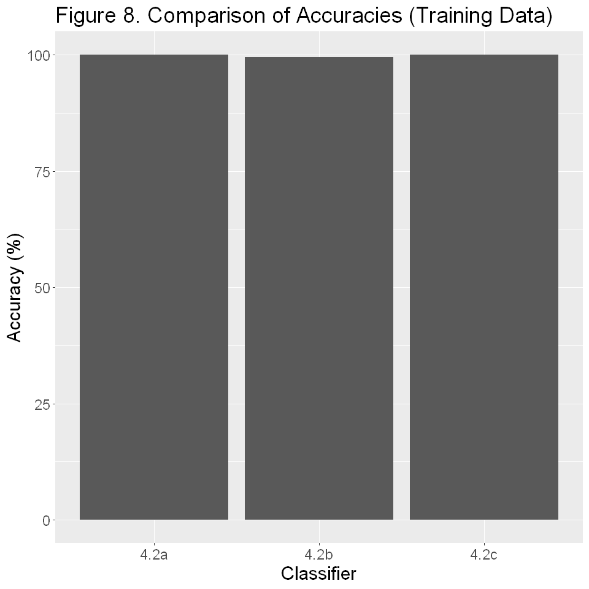

```r
options(repr.plot.width = 8, repr.plot.height = 8)
a <- data.frame(classifier="4.2a",accuracy=training_results_a$overall[1])
rownames(a) <- c()
b <- data.frame(classifier="4.2b",accuracy=training_results_b$overall[1])
rownames(b) <- c()
c <- data.frame(classifier="4.2c",accuracy=training_results_c$overall[1])
rownames(c) <- c()

rbind(a,b,c) %>% ggplot(aes(x=classifier,y=accuracy*100))+
    geom_bar(stat = "identity")+
    labs(x="Classifier",y="Accuracy (%)",cex.lab=10)+
    theme(text = element_text(size = 18))+
    ggtitle("Figure 8. Comparison of Accuracies (Training Data)")
```

## 2.10 Result (Test Data)

```r
#4.2a Follower_Count and Post_Count
k = data.frame(k = 1)
model_knn_a <- train(x = X_train_a, y = Y_train, method = "knn", tuneGrid = k)

Y_test_predicted_a <- predict(object = model_knn_a, X_test_a)

model_quality_a <- confusionMatrix(data = Y_test_predicted_a, reference = Y_test)
model_quality_a$overall[1]
```

**Accuracy:** 0.995884773662551

```r
#4.2b Friend_Count and Liked_Count
k = data.frame(k = 1)
model_knn_b <- train(x = X_train_b, y = Y_train, method = "knn", tuneGrid = k)

Y_test_predicted_b <- predict(object = model_knn_b, X_test_b)

model_quality_b <- confusionMatrix(data = Y_test_predicted_b, reference = Y_test)
model_quality_b$overall[1]
```

**Accuracy:** 0.98559670781893

```r
#4.2c Follower_Post, Post_Count, and Liked_Count
k = data.frame(k = 1)
model_knn_c <- train(x = X_train_c, y = Y_train, method = "knn", tuneGrid = k)

Y_test_predicted_c <- predict(object = model_knn_c, X_test_c)

model_quality_c <- confusionMatrix(data = Y_test_predicted_c, reference = Y_test)
model_quality_c$overall[1]
```

**Accuracy:** 0.993827160493827

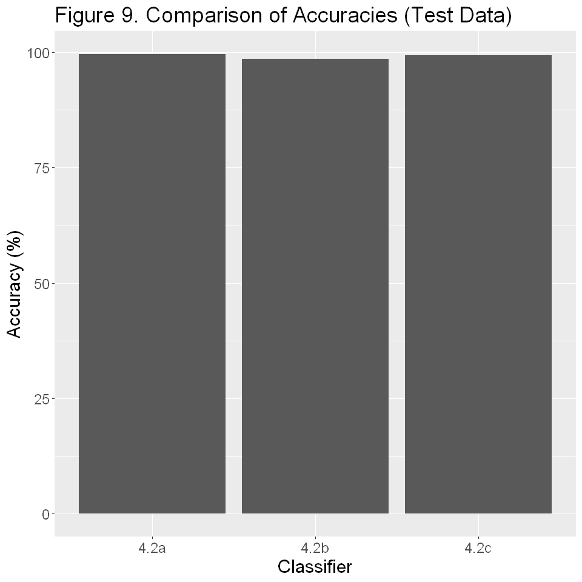

```r
options(repr.plot.width = 8, repr.plot.height = 8)
a <- data.frame(classifier="4.2a",accuracy=model_quality_a$overall[1])
rownames(a) <- c()
b <- data.frame(classifier="4.2b",accuracy=model_quality_b$overall[1])
rownames(b) <- c()
c <- data.frame(classifier="4.2c",accuracy=model_quality_c$overall[1])
rownames(c) <- c()


rbind(a,b,c) %>% ggplot(aes(x=classifier,y=accuracy*100))+
    geom_bar(stat = "identity")+
    labs(x="Classifier",y="Accuracy (%)",cex.lab=10)+
    theme(text = element_text(size = 18))+
    ggtitle("Figure 9. Comparison of Accuracies (Test Data)")
```

# 3. Discussion

According to the four numerical variables, followers, friends, posts, and likes, this project performed three different K-nn classification to process the data of 1000 Twitter accounts collected at random and calculated the accuracy of our predictions. In the Training error part, we firstly used training data to check the predicting models we got by exploring the correlation between numerical variables in the groups and whether the twitter accounts were verified. In this situation, we found that, for the training data, both predicting models of 'follower and post count' group and 'follower, post, and like count' group had the success of 100 percent while the model made by 'friends count and liked count' had an error rate of approximately 0.5 percent. After summarizing the training error rate, the next step was using the three models to predict the observations in the test data, which were never used before. The result was that predicting by the first model and the third model displayed the accuracy of 0.99588 and 0.99383, respectively, but the accuracy for the second model was slightly lower, which was 0.98560. The plot of the three groups at the last part of the code also showed their comparison of accuracy.

Because the accuracy of all the categories was extraordinarily high, and the three bars of the plot above were nearly filled, we concluded that all the groups of variables could predict whether or not a twitter account was verified. By the plot, it seems that we tend to choose the first and the third variable groups to make predictions on account of their longer bars. However, when comparing the accuracy of the first and the third group, we noticed that there was one more variable, like count, in the third group, while the accuracy was lower, conversely. Besides, the second group with the 'like count' variable also had a slightly unsatisfactory predicting result, which meant this variable did not contribute a lot as other variables to our prediction. Hence we tended to conclude that, in order to ensure the accuracy, we should avoid considering this numerical variable, like count, in the future predictions. On the other hand, because of the highest predicting accuracy of the first group, we summarized that the combination of follower and post count was the most appropriate and influential to predict the verification of twitter accounts.

However, some questions are arising from this analysis. Firstly, Twitter Verified is a status given by Twitter directly, which means there are a large number of zombie fans in the counting data. Therefore, does 'follower count matter' as much as legitimate followers? In essence, does quantity beat quality when Twitter goes through the account verification process? Furthermore, are there any instances of outliers, such as some public figures that meet all of our benchmarks but are not Twitter Verified? What are the causes of these outlier status? These questions are what would not be solved and will be explored in the future study.

# 4. References

- Can k be 1? (2020). Piazza. Retrieved from https://piazza.com/class/k4w3w9x7mbu63q?cid=336
- Pushsift.io. CSV formatted Metadata for over 115 million Twitter user accounts (including all verified accounts and nearly complete for years 2006-2009). (2019). Retrieved from https://www.reddit.com/r/datasets/comments/8v123v/csv_formatted_metadata_for_over_115_million/